# Swap Design Using Constraint Programming

DOSSEH AMECK GUY-MAX DESIRE

2025-02-26

## Interest Rate Swap (IRS) on Loans

Companies A and B have been offered the following rates per annum on a $20 million 5-year loan:

|  | Fixed Rate | Floating Rate |
| --- | --- | --- |
| Company A | 5% | SOFR+0.1% |
| Company B | 6.4% | SOFR+0.6% |

Company A requires a floating-rate loan; company B requires a fixed-rate loan. Design a swap that will net a bank, acting as intermediary, 0.1% per annum and that will appear equally attractive to both companies.

- Bank gain: 0.1%
- A: floating rate loan
- B: fixed rate loan

Let be:

- Known parameters:
  - $r_{f_{A}}$: the fixed interest rate of a loan for Company A;
  - $s_{A}$: the spread of credit in floating rate for company A;
  - $s_B$: the spread of credit in floating rate for company B;
  - $G_{bank}$: Bank profit
  - $G_A$: Company A profit
  - $G_B$: Company B profit
- Variables:
  - $r_{f_{Bk-A}}$: the fixed interest rate the bank agrees to pay to company A;
  - $s_{A-Bk}$ the spread of credit company A gives to the bank on floating rate;
  - $r_{f_{B-Bk}}$: the fixed interest rate company B pays to the bank;
  - $s_{Bk-B}$: the spread of credit the bank pays to company B on floating rate;

Let’s define a constraint satisfiability problem:

$$\begin{cases}
(r_{f_{B}}-r_{f_{B-Bk}})+(S_{Bk-B}-s_{B}) = G_B\\
(r_{f_{Bk-A}}-r_{f_{A}})+(s_{A} - s_{A-Bk}) = G_A\\
(r_{f_{B-Bk}}-r_{f_{Bk-A}})+(s_{A-Bk}-s_{Bk-B}) = G_{Bank}\\
r_{f_{Bk-A}} \leq r_{f_{B-Bk}}\\
s_{Bk-B} \leq s_{A-Bk}\\
r_{f_{Bk-A}} \geq r_{f_{A}}\\
r_{f_{B-Bk}} \leq r_{f_{B}}\\
s_{A} \geq s_{A-Bk}\\
s_{Bk-B} \leq s_B
\end{cases}$$

On 10 scale basis:

$$\begin{cases}
10(r_{f_{B}}-s_{B})+(S_{Bk-B}-r_{f_{B-Bk}}) = 10 G_B\\
(r_{f_{Bk-A}}- s_{A-Bk})+10(s_{A} -r_{f_{A}}) = 10G_A\\
(r_{f_{B-Bk}}-r_{f_{Bk-A}})+(s_{A-Bk}-s_{Bk-B}) = 10G_{Bank}\\
r_{f_{Bk-A}} \leq r_{f_{B-Bk}}\\
s_{Bk-B} \leq s_{A-Bk}\\
r_{f_{Bk-A}} \geq 10r_{f_{A}}\\
r_{f_{B-Bk}} \leq 10r_{f_{B}}\\
10s_{A} \geq s_{A-Bk}\\
s_{Bk-B} \leq 10s_B
\end{cases}$$

### Finding solutions

```python
class VarArraySolutionPrinter(cp_model.CpSolverSolutionCallback):
    """Print intermediate solutions."""

    def __init__(self, variables, max_dec_digits):
        cp_model.CpSolverSolutionCallback.__init__(self)
        self.__variables = variables
        self.max_dec_digits = max_dec_digits
        self.__solution_count = 0
        self.solutions = []


    def on_solution_callback(self):
        self.__solution_count += 1
        # for v in self.__variables:
        #     print(f"{v}={self.Value(v)/self.max_dec_digits:.2f}", end=" ")
        # print()
        self.solutions.append({v.Name(): self.Value(v)/self.max_dec_digits for v in self.__variables})

    @property
    def solution_count(self):
        return self.__solution_count


def search_for_all_solutions_sample_sat( rf_A, rf_B, s_A, s_B, G_B, G_A, G_bank):
    """Showcases calling the solver to search for all solutions."""
    # Creates the model.
    model = cp_model.CpModel()
    max_dec_digits = 10**max([len(x) for x in [str(rate).split(".")[-1] for rate in [rf_A, rf_B, s_A, s_B]]])

    rates_upper_bound = int(max_dec_digits*max(rf_A, rf_B))
    # Define the variables
    r_f_B_Bk = model.NewIntVar(0, rates_upper_bound, 'r_f_B_Bk')  # Upper bound 64.0
    s_Bk_B = model.NewIntVar(-int(max_dec_digits*s_B), int(max_dec_digits*s_B), 's_Bk_B')       # Upper bound 6.0
    r_f_Bk_A = model.NewIntVar(0, rates_upper_bound, 'r_f_Bk_A')  # Upper bound 64.0
    s_A_Bk = model.NewIntVar(-int(max_dec_digits*s_A), int(max_dec_digits*s_A), 's_A_Bk')       # Upper bound 1.0

    # Define the constraints
    model.Add(int(max_dec_digits*(rf_B-s_B)) - r_f_B_Bk + s_Bk_B == int(max_dec_digits*G_B))  # 58 - r_f_B_Bk + s_Bk_B == 4
    model.Add(r_f_Bk_A - s_A_Bk + int(max_dec_digits*(s_A-rf_A))== int(max_dec_digits*G_A))  # r_f_Bk_A - 49 - s_A_Bk == 4
    model.Add(r_f_B_Bk - r_f_Bk_A + s_A_Bk - s_Bk_B == int(max_dec_digits*G_bank))  # r_f_B_Bk - r_f_Bk_A + s_A_Bk - s_Bk_B == 1
    # model.Add(r_f_Bk_A <= r_f_B_Bk)
    # model.Add(s_Bk_B <= s_A_Bk)
    model.Add(r_f_Bk_A >= int(max_dec_digits*rf_A))
    model.Add(r_f_B_Bk <= int(max_dec_digits*rf_B))
    model.Add(s_A_Bk <= int(max_dec_digits*s_A))
    model.Add(s_Bk_B <= int(max_dec_digits*s_B))

    # Create a solver and solve.
    solver = cp_model.CpSolver()
    solution_printer = VarArraySolutionPrinter([r_f_B_Bk, s_Bk_B, r_f_Bk_A, s_A_Bk], max_dec_digits)
    # Enumerate all solutions.
    solver.parameters.enumerate_all_solutions = True
    # Solve.
    status = solver.Solve(model, solution_printer)

    print(f"Status = {solver.StatusName(status)}")
    print(f"Number of solutions found: {solution_printer.solution_count}")
    return solution_printer.solutions


solutions = search_for_all_solutions_sample_sat(5, 6.4, 0.1, 0.6, 0.4, 0.4, 0.1)
```

```
## Status = OPTIMAL
## Number of solutions found: 39
```

```python
pd.DataFrame(solutions).to_csv("solutions.csv", index=False)
pd.DataFrame(solutions)
```

```
##     r_f_B_Bk  s_Bk_B  r_f_Bk_A  s_A_Bk
## 0        4.8    -0.6       5.2    -0.1
## 1        4.8    -0.6       5.3     0.0
## 2        4.8    -0.6       5.4     0.1
## 3        4.9    -0.5       5.4     0.1
## 4        4.9    -0.5       5.3     0.0
## 5        5.0    -0.4       5.3     0.0
## 6        5.0    -0.4       5.4     0.1
## 7        5.1    -0.3       5.4     0.1
## 8        5.1    -0.3       5.3     0.0
## 9        5.2    -0.2       5.3     0.0
## 10       5.2    -0.2       5.4     0.1
## 11       5.3    -0.1       5.4     0.1
## 12       5.3    -0.1       5.3     0.0
## 13       5.4     0.0       5.3     0.0
```

[output cut: 25 more lines]

### Drawing some of the solutions

- **Function to draw solution**

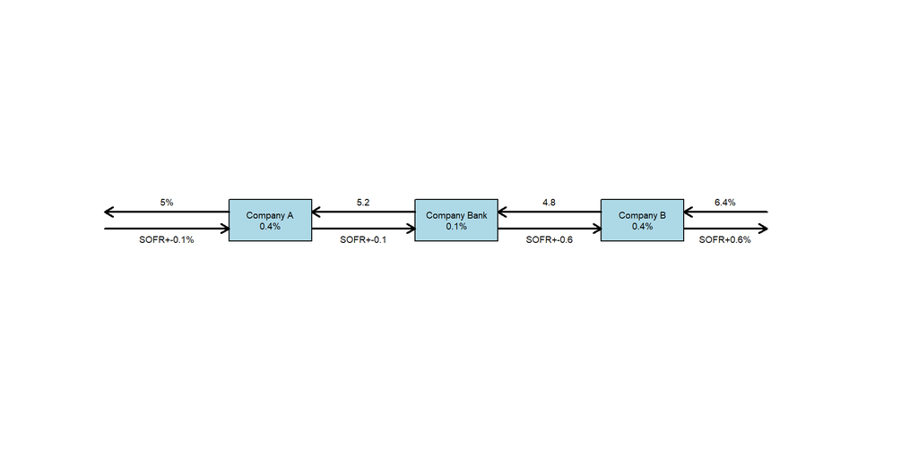

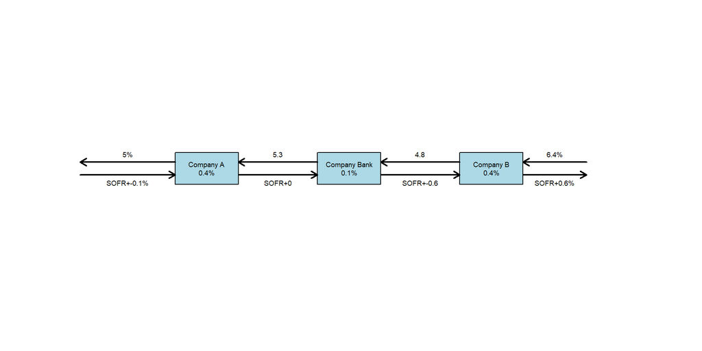

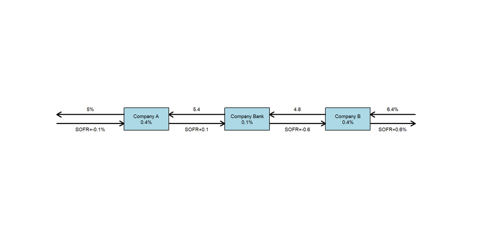

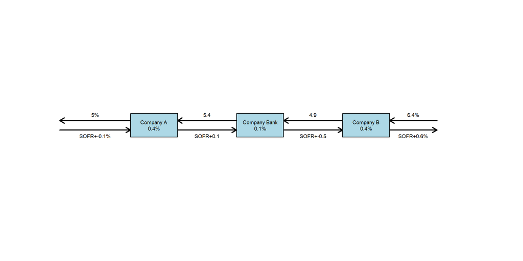

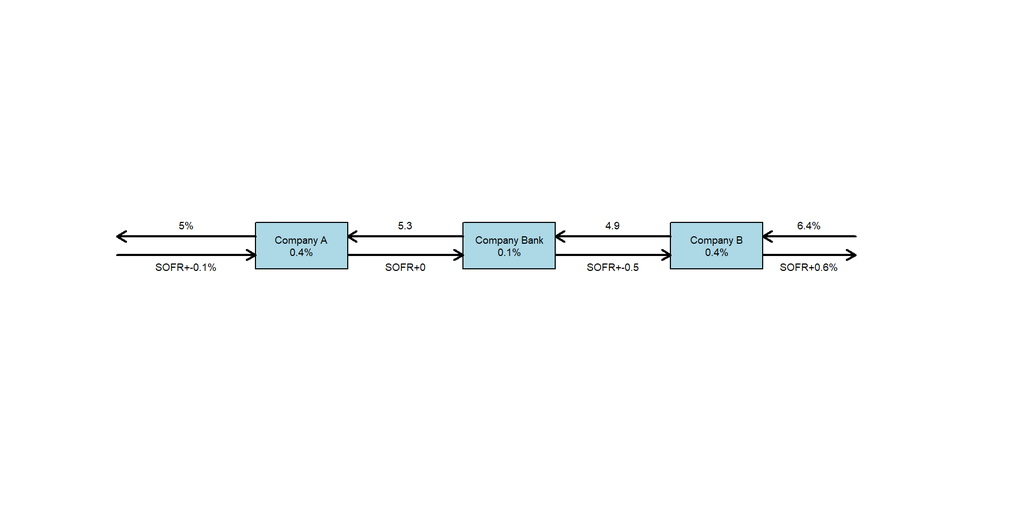

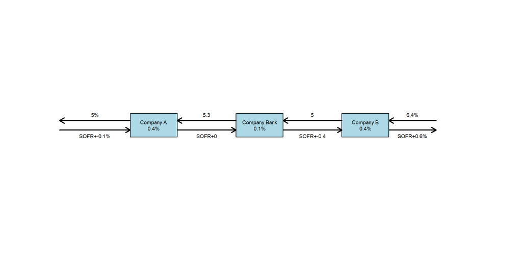

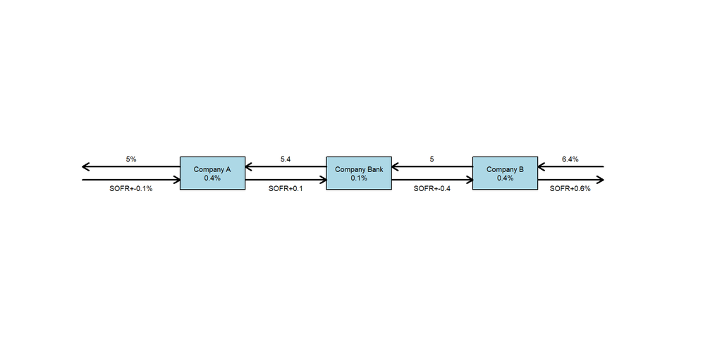

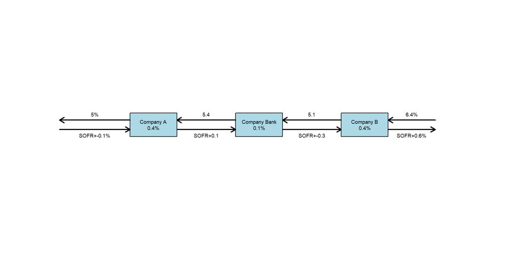

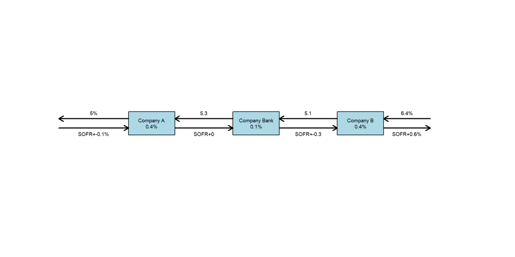

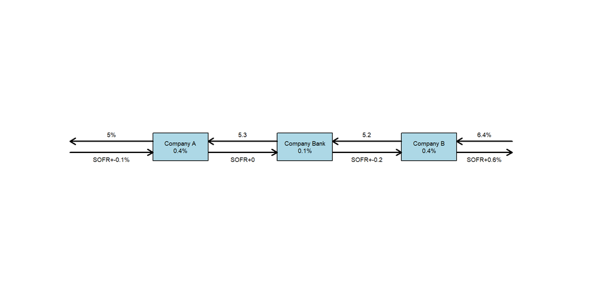

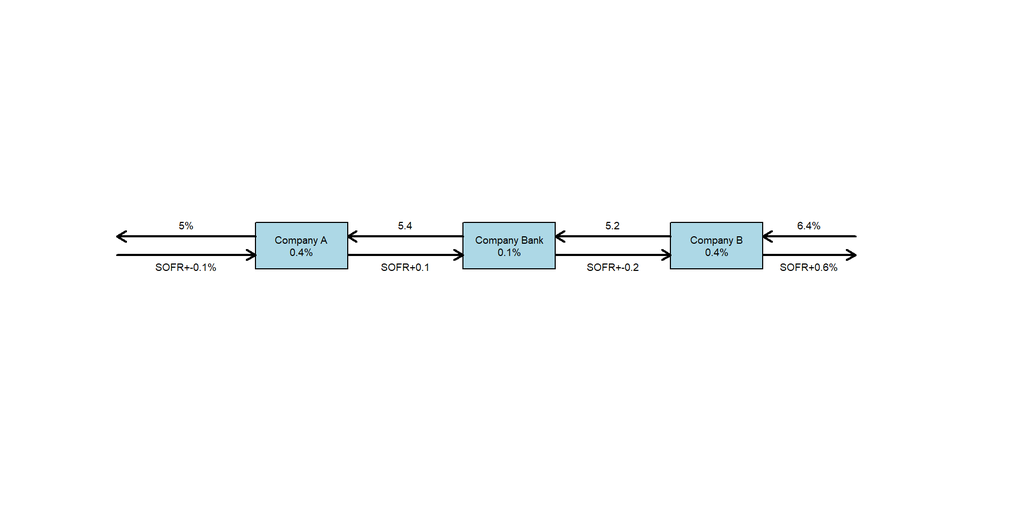

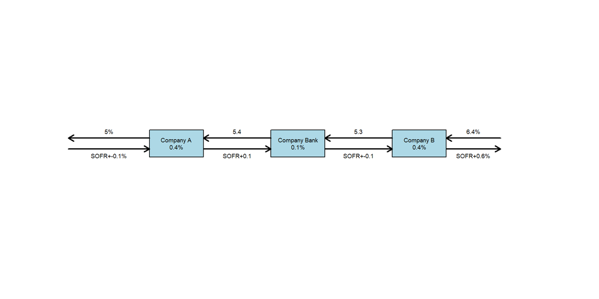

[27 more figures not shown]

```r
plotDiagram <- function(rf_A, rf_B, s_A, s_B, G_B, G_A, G_bank, s_A_Bk, s_Bk_B, rf_B_Bk, rf_Bk_A, Company_A, Company_B, Bank, floating_rate) {
  # Set up an empty plot with vertical limits exactly covering the diagram.
  plot(NA, NA,
       xlim = c(-4, 14), ylim = c(0, 0),
       type = "n", axes = FALSE, xlab = "", ylab = "", asp = 1)

  # Define node positions and dimensions.
  # Company A: centered at (0, 0)
  A.center <- c(0, 0)
  A.left <- -1; A.right <- 1; A.top <- 0.5; A.bot <- -0.5

  # Bank: shifted further to the right
  Bank.center <- c(4.5, 0)
  Bank.left <- 3.5; Bank.right <- 5.5; Bank.top <- 0.5; Bank.bot <- -0.5

  # Company B: shifted further to the right
  B.center <- c(9, 0)
  B.left <- 8; B.right <- 10; B.top <- 0.5; B.bot <- -0.5

  # Draw nodes as rectangles with text inside.
  rect(A.left, A.bot, A.right, A.top, col = "lightblue")
  text(A.center[1], A.center[2], paste("Company ", Company_A, "\n", G_A, sep = ""), cex = 0.6)

  rect(Bank.left, Bank.bot, Bank.right, Bank.top, col = "lightblue")
  text(Bank.center[1], Bank.center[2], paste("Company ", Bank, "\n", G_bank, sep = ""), cex = 0.6)

  rect(B.left, B.bot, B.right, B.top, col = "lightblue")
  text(B.center[1], B.center[2], paste("Company ", Company_B, "\n", G_B, sep = ""), cex = 0.6)

  # Helper function to add an arrow with a label.
  add_arrow <- function(x0, y0, x1, y1, label, label_offset = 0.1, side = "above") {
    arrows(x0, y0, x1, y1, code = 2, length = 0.1, lwd = 2)
    xm <- (x0 + x1) / 2
    ym <- (y0 + y1) / 2
    if (side == "above") {
      text(xm, ym + label_offset, label, cex = 0.6)
    } else {
      text(xm, ym - label_offset, label, cex = 0.6)
    }
  }

  # Draw arrows using positions computed to mimic the desired offsets.
  add_arrow(A.left, 0.2, A.right - 5, 0.2, rf_A, label_offset = 0.25, side = "above")
  add_arrow(A.right - 5, -0.2, A.left, -0.2, paste(floating_rate, s_A, sep="+"), label_offset = 0.25, side = "below")
  add_arrow(Bank.left, 0.2, A.right, 0.2, rf_Bk_A, label_offset = 0.25, side = "above")
  add_arrow(B.left, 0.2, Bank.right, 0.2, rf_B_Bk, label_offset = 0.25, side = "above")
  add_arrow(A.right, -0.2, Bank.left, -0.2, paste(floating_rate, s_A_Bk, sep="+"), label_offset = 0.25, side = "below")
  add_arrow(Bank.right, -0.2, B.left, -0.2, paste(floating_rate, s_Bk_B, sep="+"), label_offset = 0.25, side = "below")
  add_arrow(B.right + 2, 0.2, B.right, 0.2, rf_B, label_offset = 0.25, side = "above")
  add_arrow(B.right, -0.2, B.right + 2, -0.2, paste(floating_rate, s_B, sep="+"), label_offset = 0.25, side = "below")
}
```

## Interest Rate Swap (IRS) on Investments

Companies X and Y have been offered the following rates per annum on a $5 million 10-year investment:

|  | Fixed Rate | Floating Rate |
| --- | --- | --- |
| Company X | 8.0% | LIBOR |
| Company Y | 8.8% | LIBOR |

Company X requires a fixed-rate investment; company Y requires a floating-rate investment. Design a swap that will net a bank, acting as intermediary, 0.2% per annum and will appear equally attractive to X and Y.

- Bank gain: 0.2%
- X: fixed rate investment
- Y: floating rate investment
- Equal gain for X and Y: 0.3%

### Finding solutions

```python
solutions = search_for_all_solutions_sample_sat(8, 8.8, 0.0, 0.0, 0.3, 0.3, 0.2)
```

```
## Status = OPTIMAL
## Number of solutions found: 1
```

```python
pd.DataFrame(solutions).to_csv("solutions.csv", index=False)
pd.DataFrame(solutions)
```

```
##    r_f_B_Bk  s_Bk_B  r_f_Bk_A  s_A_Bk
## 0       8.5     0.0       8.3     0.0
```

### Drawing the solution

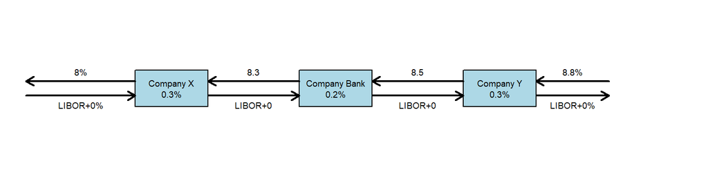